# Red Wine Quality by Alex Raya

> Based on these multivariate plots, we can now begin to show which chemicals factor most into the quality of the wine: volatile acidity, alcohol, sulphates and citric acid.

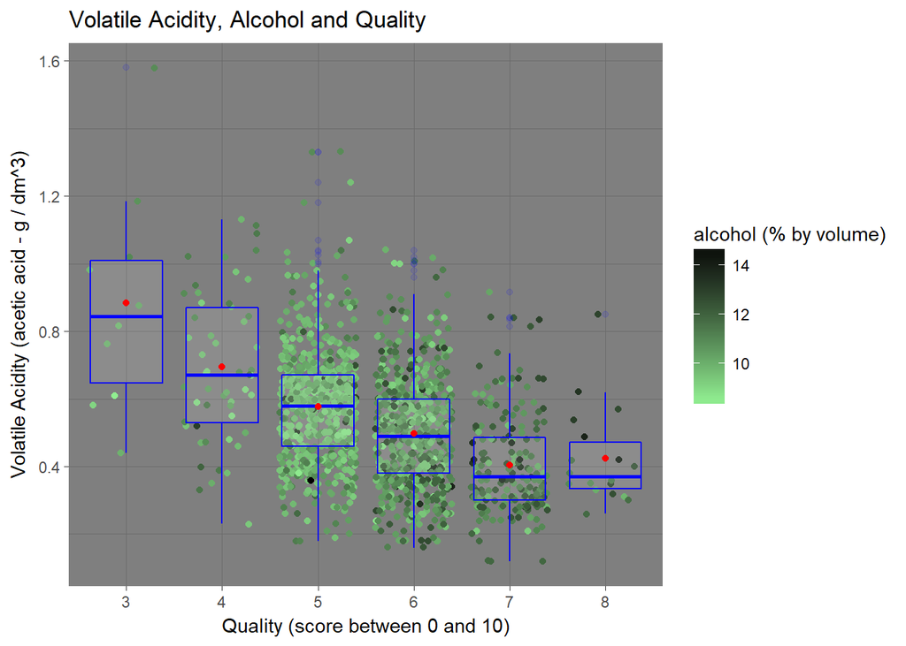

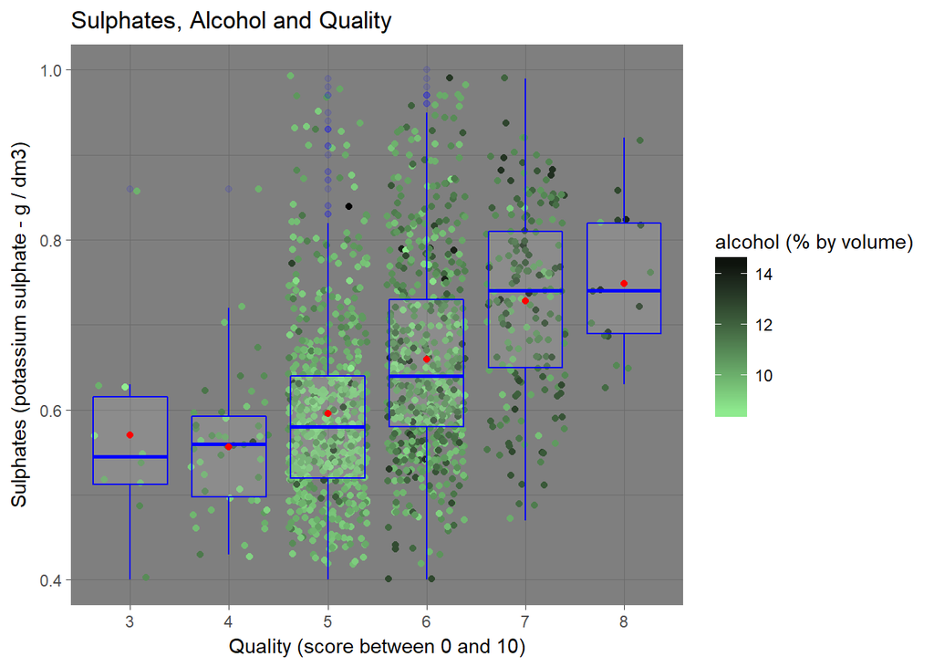

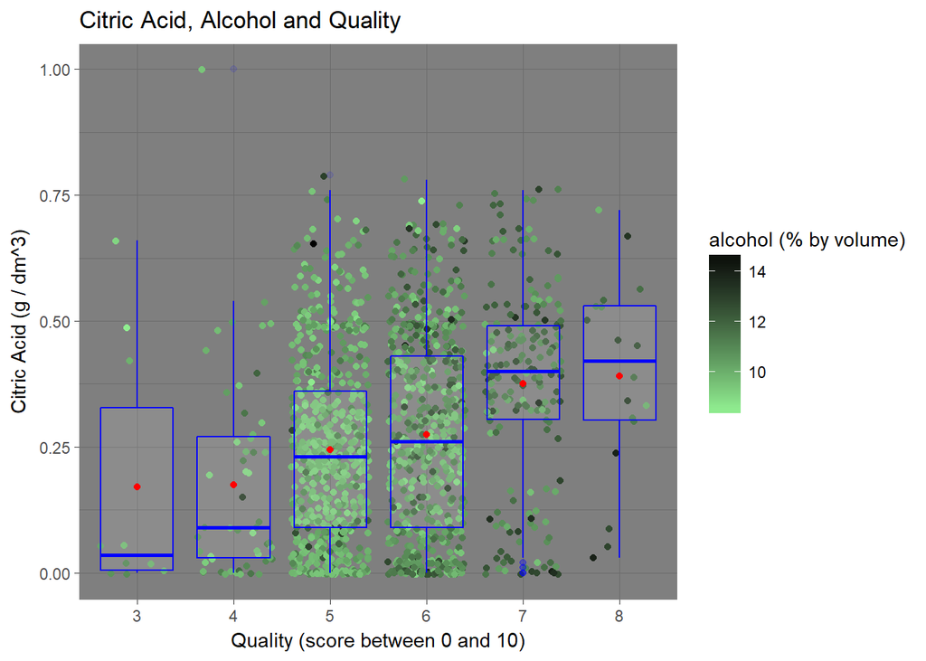

# Multivariate Analysis

### Were there any interesting or surprising interactions between features?

> From the interactions seen from the plots, an assumption can be made that alcohol and volatile acidity have outsized proportionality of correlation to quality compared to other values with smaller correlation coefficients, while factors like fixed acidity, which had little correlation to quality, correlates strongly with citric acid and perhaps other factors, which is peculiar.

```r
m1 <- lm(I(quality) ~ I(alcohol), data = subset(pf, quality > 3))
m2 <- update(m1, ~ . + volatile.acidity)
m3 <- update(m2, ~ . + sulphates)
m4 <- update(m3, ~ . + citric.acid)
mtable(m1, m2, m3, m4, sdigits = 3)
```

```
##
## Calls:
## m1: lm(formula = I(quality) ~ I(alcohol), data = subset(pf, quality >
##     3))
## m2: lm(formula = I(quality) ~ I(alcohol) + volatile.acidity, data = subset(pf,
##     quality > 3))
## m3: lm(formula = I(quality) ~ I(alcohol) + volatile.acidity + sulphates,
##     data = subset(pf, quality > 3))
## m4: lm(formula = I(quality) ~ I(alcohol) + volatile.acidity + sulphates +
##     citric.acid, data = subset(pf, quality > 3))
##
## ============================================================================
##                          m1            m2            m3            m4
## ----------------------------------------------------------------------------
##   (Intercept)           1.945***      3.052***      2.566***      2.578***
##                        (0.169)       (0.181)       (0.191)       (0.197)
##   I(alcohol)            0.356***      0.313***      0.308***      0.308***
##                        (0.016)       (0.016)       (0.015)       (0.015)
##   volatile.acidity                   -1.255***     -1.093***     -1.109***
##                                      (0.095)       (0.096)       (0.112)
##   sulphates                                         0.682***      0.687***
##                                                    (0.098)       (0.100)
##   citric.acid                                                    -0.027
##                                                                  (0.102)
## ----------------------------------------------------------------------------
##   R-squared             0.235         0.311         0.331         0.331
##   adj. R-squared        0.234         0.310         0.330         0.330
##   sigma                 0.685         0.650         0.640         0.641
##   F                   487.453       357.847       261.806       196.257
##   p                     0.000         0.000         0.000         0.000
##   Log-likelihood    -1651.582     -1568.495     -1544.618     -1544.583
##   Deviance            743.785       669.931       650.097       650.069
##   AIC                3309.165      3144.990      3099.237      3101.167
##   BIC                3325.277      3166.473      3126.091      3133.392
##   N                  1589          1589          1589          1589
## ============================================================================
```

```r
pf[444,]
```

```
##     fixed.acidity volatile.acidity citric.acid residual.sugar chlorides
## 444            10             0.44        0.49            2.7     0.077
##     free.sulfur.dioxide total.sulfur.dioxide density   pH sulphates
## 444                  11                   19  0.9963 3.23      0.63
##     alcohol quality
## 444    11.6       7
```

```r
thisredwine = data.frame(alcohol = 10,
                         volatile.acidity = 0.33,
                         sulphates = 1.1,
                         citric.acid = 0.33
                         )

modelEstimate = predict(m4, newdata = thisredwine,
                        interval="prediction", level = .95)

modelEstimate
```

```
##        fit      lwr      upr
## 1 6.040043 4.779783 7.300303
```

```r
message('Difference of model example result and actual: ', (1 - (6.04 / 7)))
```

```
## Difference of model example result and actual: 0.137142857142857
```

> This linear model created with a subset of the data where quality > 3 produces a fit of quality that is less than the actual by about 14%, however this dataset is affected by two primary issues, quality is highly concentrated in values of 5 and 6, and no values have very strong correlation coefficients with quality individually, so any linear model is going to be affected by this skew in the data, as well as the lack of strong correlating values, but the actual value is within the fit and upper range of the model created, so it has some validity on its own if understood with that reservation.

# Final Plots and Summary

### Plot One

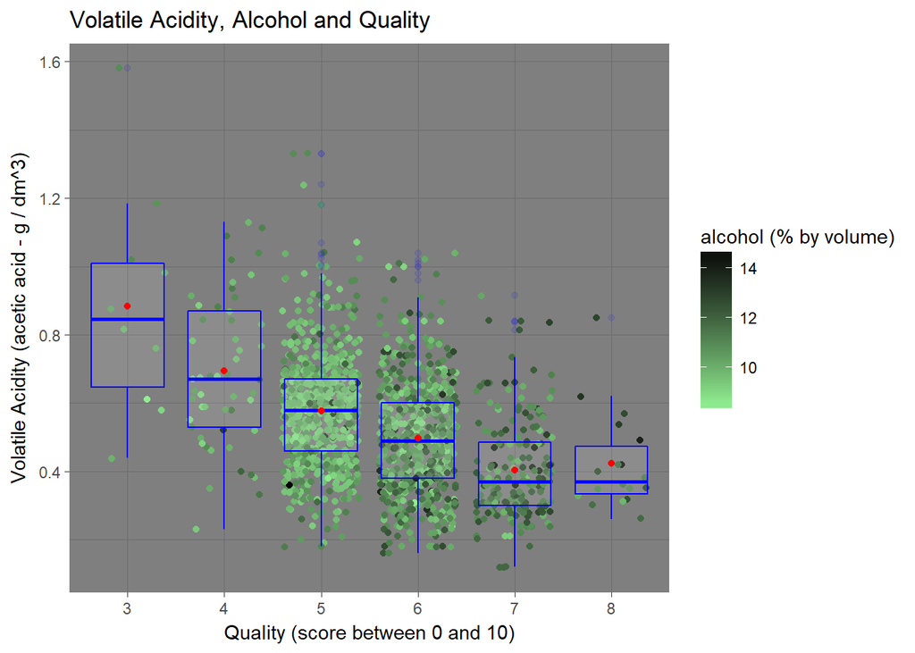

### Description One

> This plot displays quality box plots versus volatile acidity with alcohol by color, what is worth noticing is that wines have lower volatile acidity and higher alcohol content as quality increases. Therefore, volatile acidity and alcohol are affecting the wine quality, apparently.

### Plot Two

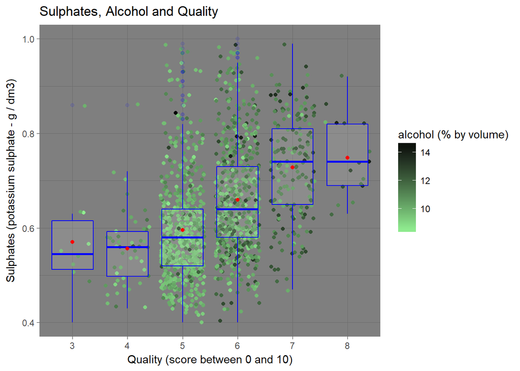

### Description Two

> This plot displays quality box plots versus sulphates with alcohol by color, and sulphates and alcohol content increase as quality increases. Based on this trend, sulphates are affecting the quality of the wine.

### Plot Three

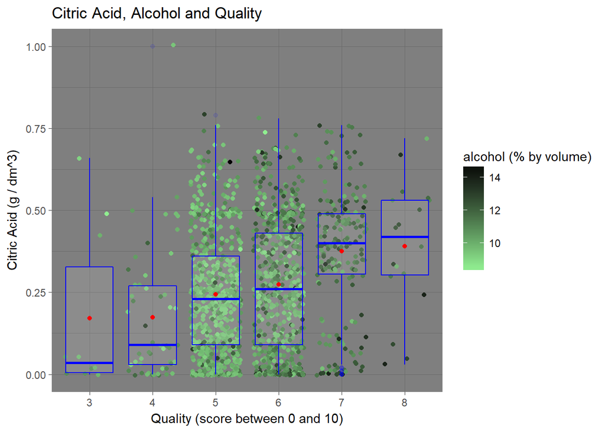

### Description Three

> This plot displays quality box plots versus citric acid with alcohol in color, and higher quality wines had higher citric acid and alcohol content. Based on the trend seen here, citric acid is affecting the quality of the wine.

# Reflection

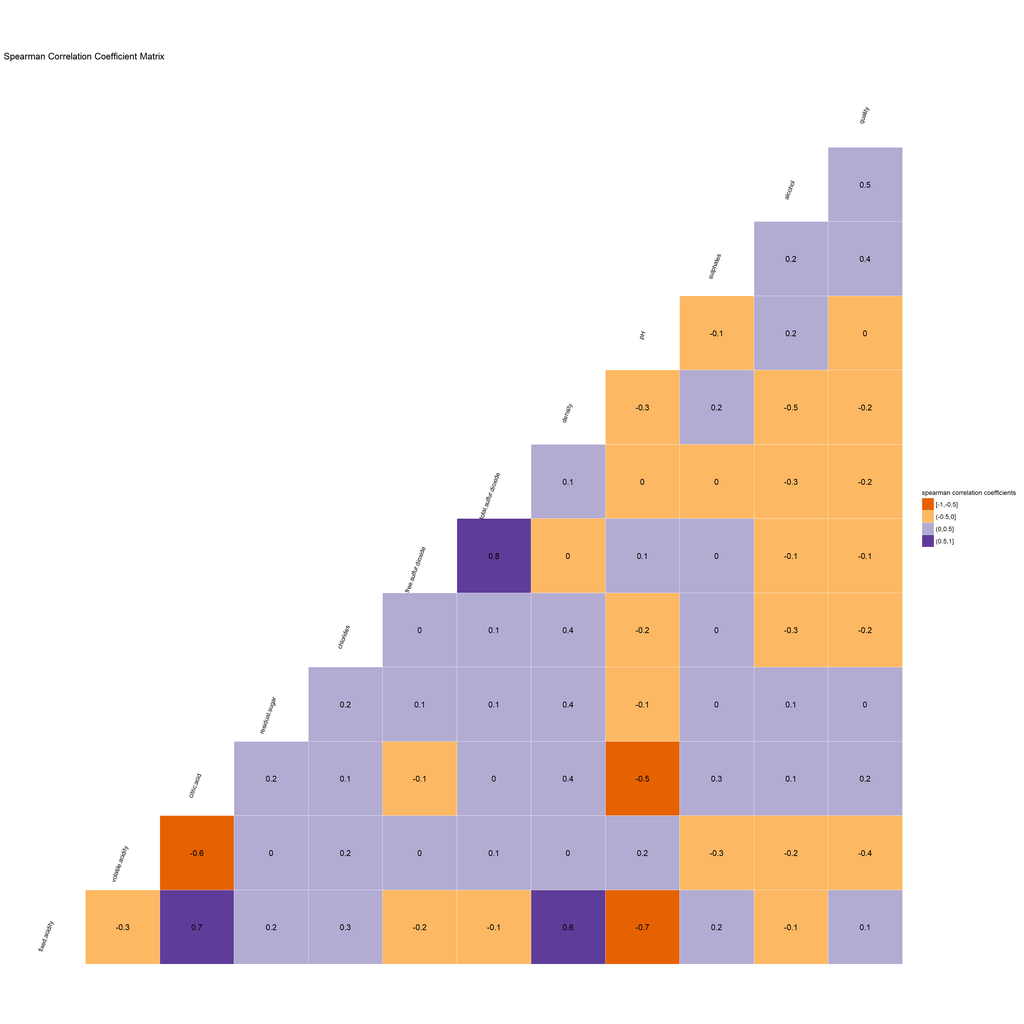

> Even though this was not a complicated dataset, there was a good amount of work necessary to understand what values in the dataset appeared to have some impact on quality, which was difficult to see initially since there are no values with a strong correlation with quality visible immediately, as seen above in a Spearman correlation coefficient matrix. Initial plots and correlation calculations produced some ideas of how to proceed with certain factors that had acceptable correlation to quality, and after some of those intial plots were done, some insight arose; alcohol, volatile acidity, sulphates, and citric acid were seen to have some correlations to quality and therefore were apparently impactful upon the quality of the wine, and thus when they are analyzed together in multivariable analysis with some box plotting for quality, a relationship began to emerge whereby wines of higher quality had higher alcohol content, lower volatile acidity, higher sulphates and higher citric acid. This insight took some time to arrive at, but by proceeding through single variable, bivariable then multivarable analysis, this assumption was able to be established.

> An issue found in this dataset and an improvement that would make this analysis more insightful would be to have more data on a larger variety of wine quality so as to fill out the data better, on a quality scale of 0 to 10 this dataset has mostly wines concentrated in the quality of 5 and 6, therefore determining what values affected quality is has the reservation of being too narrow because of that dataskew, having more data on lesser and finer wines could provide more effective insight for determining what relationships of chemical components are most impactful on quality overall, beyond just wines rated 5-6 out of 10.